# Homework 2 Report

## Name

**Pranjal Mandal**

### Setup

Read in the data with `read_csv()` and store the data as an R object named `dataset`. Check the data to make sure all of the expected observations and variables are there.

```r
## Load the data and any necessary packages here.
 dataset <- read.csv(gzfile("maacs (5).csv.gz"), stringsAsFactors = FALSE)
 dim(dataset)
```

```
## [1] 150  10
```

```r
 str(dataset)
```

```
## 'data.frame':    150 obs. of  10 variables:
##  $ id            : chr  "fd171e2d" "a66fc33a" "fc038e68" "8e28b8c2" ...
##  $ age           : num  14.7 13.6 14.5 14 16.6 ...
##  $ gender        : chr  "male" "female" "male" "female" ...
##  $ fev1          : num  1.78 2.12 2.73 2.36 3.13 2.59 2.6 3.49 2.29 2.37 ...
##  $ eNO           : num  141 68 210 23 18 128 19 26 17 134 ...
##  $ cough_days    : int  2 8 2 0 14 0 0 4 1 14 ...
##  $ pm25          : num  15.6 18.9 17.8 14 17.9 ...
##  $ no2           : num  NA 12.8 NA NA 31 ...
##  $ mouse         : int  2423 939 200 NA 10371 4789 760 264 419 187 ...
##  $ mouse_allergic: chr  "yes" "yes" "no" "no" ...
```

```r
 summary(dataset[, c("age", "fev1")])
```

```
##       age              fev1
##  Min.   : 5.000   Min.   :0.650
##  1st Qu.: 7.713   1st Qu.:1.370
##  Median :10.915   Median :1.870
##  Mean   :11.215   Mean   :1.994
##  3rd Qu.:14.758   3rd Qu.:2.490
##  Max.   :17.890   Max.   :5.000
##                   NA's   :17
```

```r
 sum(!is.na(dataset$age) & !is.na(dataset$fev1))
```

```
## [1] 133
```

## Part 1

We will first consider the relationship between FEV1 and age. In general, it is expected that as children get older (and hence, larger in size), their FEV1 values should get higher.

Consider the statement “FEV1 values in children are higher in older children relative to younger children”.

Write a function in R that takes the `dataset` object as an argument and returns `TRUE` if the statement above is true for the dataset and `FALSE` otherwise.

NOTE: In order to write this function, you will need to translate the statement above into something that can be checked with the data. There are many ways in which you can do that translation correctly and you only need to pick one way here.

NOTE: For this part, do not use any plots.

```r
## Write your function here
fev1_higher_in_older <- function(dataset) {
  d <- dataset[!is.na(dataset$age) & !is.na(dataset$fev1), c("age","fev1")]
  if (nrow(d) < 2) return(FALSE)
  med_age <- stats::median(d$age)
  older_mean   <- mean(d$fev1[d$age >  med_age])
  younger_mean <- mean(d$fev1[d$age <= med_age])
  isTRUE(older_mean > younger_mean)}
fev1_higher_in_older(dataset)
```

```
## [1] TRUE
```

## Part 2

Fit a linear regression model with FEV1 as the outcome and age as a predictor.

How much does FEV1 change for a 1-year increase in the child’s age?

```r
## Add your code here
lm_age <- lm(fev1 ~ age, data = dataset)
summary(lm_age)
```

```
##
## Call:
## lm(formula = fev1 ~ age, data = dataset)
##
## Residuals:
##      Min       1Q   Median       3Q      Max
## -1.51099 -0.27100  0.00196  0.23616  2.15477
##
## Coefficients:
##              Estimate Std. Error t value Pr(>|t|)
## (Intercept) -0.001199   0.134696  -0.009    0.993
## age          0.171162   0.010984  15.583   <2e-16 ***
## ---
## Signif. codes:  0 '***' 0.001 '**' 0.01 '*' 0.05 '.' 0.1 ' ' 1
##
## Residual standard error: 0.4827 on 131 degrees of freedom
##   (17 observations deleted due to missingness)
## Multiple R-squared:  0.6496, Adjusted R-squared:  0.6469
## F-statistic: 242.8 on 1 and 131 DF,  p-value: < 2.2e-16
```

```r
confint(lm_age)["age", , drop = FALSE]
```

```
##         2.5 %    97.5 %
## age 0.1494341 0.1928904
```

## Part 3

Develop **three** supporting premises derived from the data that support the statement you wrote in Part 2. These can be plots, other summary statistics, or model results.

NOTE:

- At least one supporting premise should use a plot.
- Do not use the code you write in Part 1 as a supporting premise

```r
## Add your code here
cor.test(dataset$age, dataset$fev1, use = "complete.obs", method = "pearson")
```

```
##
##  Pearson's product-moment correlation
##
## data:  dataset$age and dataset$fev1
## t = 15.583, df = 131, p-value < 2.2e-16
## alternative hypothesis: true correlation is not equal to 0
## 95 percent confidence interval:
##  0.7368348 0.8584229
## sample estimates:
##       cor
## 0.8059696
```

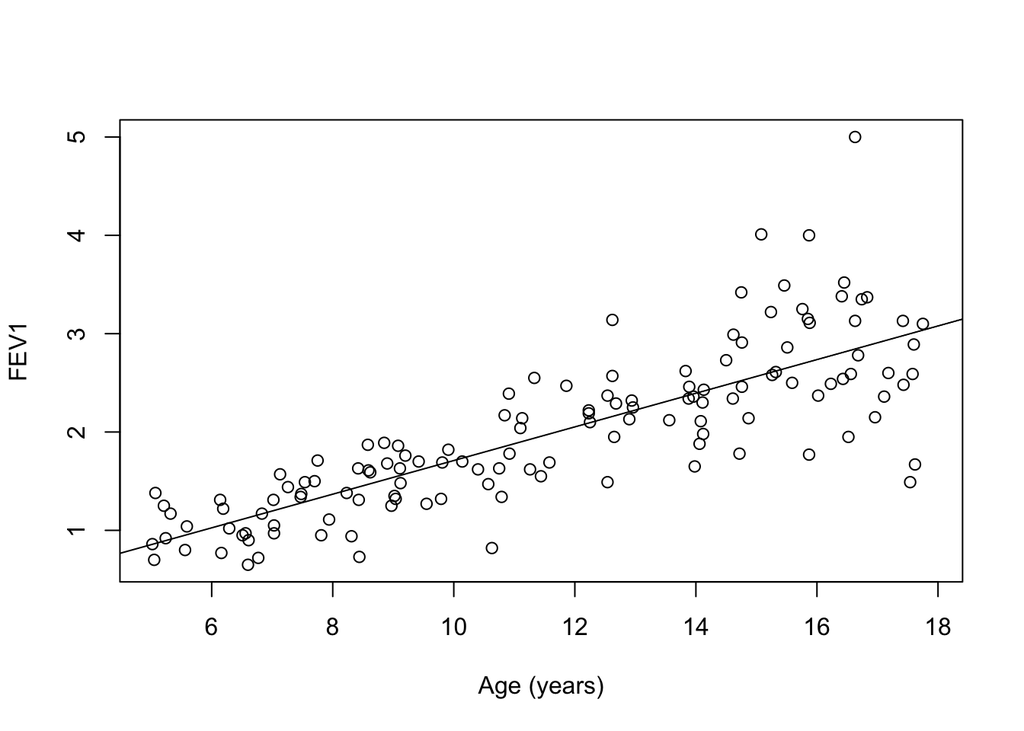

```r
plot(dataset$age, dataset$fev1, xlab = "Age (years)", ylab = "FEV1")
abline(lm(fev1 ~ age, data = dataset))
```

```r
d  <- dataset[!is.na(dataset$age) & !is.na(dataset$fev1), c("age","fev1")]
qs <- stats::quantile(d$age, probs = c(0.25, 0.75), na.rm = TRUE)
mean_bot_q <- mean(d$fev1[d$age <= qs[1]])
mean_top_q <- mean(d$fev1[d$age >= qs[2]])
c(mean_bot_q = mean_bot_q, mean_top_q = mean_top_q, diff = mean_top_q - mean_bot_q)
```

```
## mean_bot_q mean_top_q       diff
##   1.143235   2.867059   1.723824
```

Write the three supporting premise statements here:

1. **The Pearson correlation between age and FEV1 is positive and statistically significant**

   **(p < 0.05).**
2. **The scatterplot with a fitted line shows an upward trend of FEV1 with increasing age.**
3. **The mean FEV1 in the oldest age quartile exceeds the mean FEV1 in the youngest quartile.**

## Part 4

For each of the supporting premises above, write a function that takes the `dataset` object as an argument and returns `TRUE` if the supporting premise statement above is true for the dataset and `FALSE` otherwise.

For statements involving plots, instead of returning `TRUE` or `FALSE`, you function should do two things:

1. Produce the plot that is used in the statement
2. Produce a hypothetical version of the plot in the event that the statement is true. This can be done using simulated data or by simply hand drawing a plot.

```r
## Function for supporting premise statement 1
premise1_positive_correlation <- function(dataset) {
  d <- dataset[!is.na(dataset$age) & !is.na(dataset$fev1), c("age","fev1")]
  if (nrow(d) < 3) return(FALSE)
  ct <- cor.test(d$age, d$fev1, method = "pearson")
  isTRUE(unname(ct$estimate) > 0 & ct$p.value < 0.05)}
premise1_positive_correlation(dataset)
```

```
## [1] TRUE
```

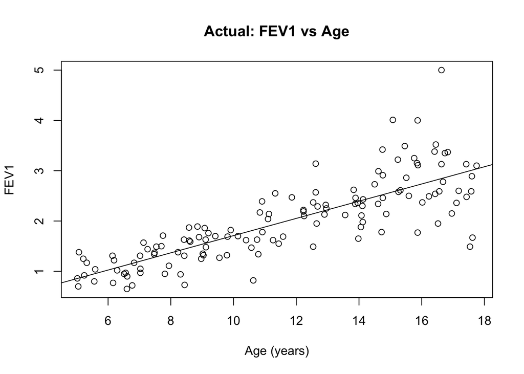

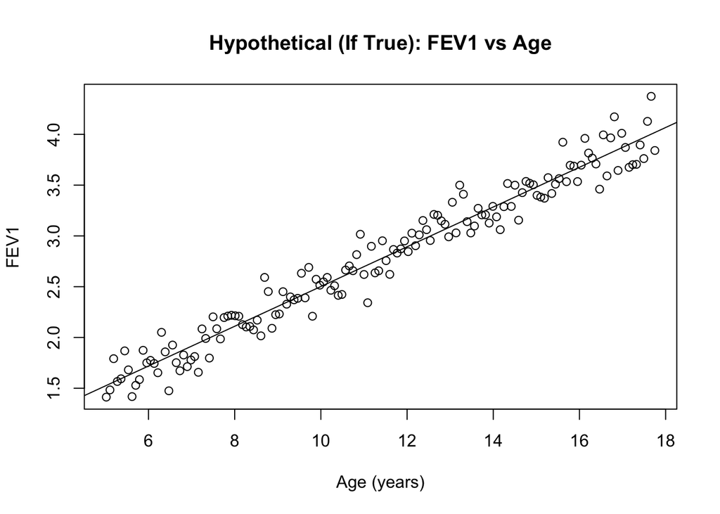

```r
## Function for supporting premise statement 2
premise2_plot_upward <- function(dataset) {
  d <- dataset[!is.na(dataset$age) & !is.na(dataset$fev1), c("age","fev1")]
  if (nrow(d) < 2) return(invisible(NULL))
  plot(d$age, d$fev1, xlab = "Age (years)", ylab = "FEV1", main = "Actual: FEV1 vs Age")
  abline(lm(fev1 ~ age, data = d))
  set.seed(123)
  age_sim <- seq(min(d$age), max(d$age), length.out = 150)
  fev1_sim <- 0.5 + 0.2 * age_sim + rnorm(length(age_sim), sd = stats::sd(d$fev1, na.rm = TRUE)/5)
  plot(age_sim, fev1_sim, xlab = "Age (years)", ylab = "FEV1", main = "Hypothetical (If True): FEV1 vs Age")
  abline(lm(fev1_sim ~ age_sim))
  invisible(NULL)}
premise2_plot_upward(dataset)
```

```r
## Function for supporting premise statement 3
premise3_quartile_means <- function(dataset) {
  d  <- dataset[!is.na(dataset$age) & !is.na(dataset$fev1), c("age","fev1")]
  if (nrow(d) < 4) return(FALSE)
  qs <- stats::quantile(d$age, probs = c(0.25, 0.75), na.rm = TRUE)
  mean_top <- mean(d$fev1[d$age >= qs[2]])
  mean_bot <- mean(d$fev1[d$age <= qs[1]])
  isTRUE(mean_top > mean_bot)}
premise3_quartile_means(dataset)
```

```
## [1] TRUE
```

Execute each of your function and show that the produce the expected output.

## Part 5

Describe one alternative to the primary statement “FEV1 values in children are higher in older children relative to younger children”.

Create a fault tree for the alternative outcome describing how the alternative outcome could be realized in the data even if the primary statement were true.

Your fault tree should be created as a separate image and does not need to be created in R. Upload the image of the fault tree to Canvas.